# Assignment 2: Comparing cluster methods

Nina van Gerwen (1860852)

2023-01-14

## Comparing cluster methods

### Describing the dataset

For my dataset, I chose the ‘Estimation of obesity levels based on eating habits and condition’ data, gained from the [UCI Machine Learning Repository](https://archive.ics.uci.edu/ml/datasets/Estimation+of+obesity+levels+based+on+eating+habits+and+physical+condition+#). The raw data contains a total of 2111 observations on 17 variables. The data was gained from individuals in Mexico, Peru and Colombia. The variables include demographic information (e.g., gender, age), variables related to their food intake (e.g., FAVC: frequent consumption of high caloric food, FCVC: frequency of consumption of vegetables, NCP: number of main meals, etc.) and finally variables related to physical condition (e.g., SCC: calories consumption monitoring, FAF: physical activity frequency, etc.). A full description of all variables can be found [here](https://www-sciencedirect-com.proxy.library.uu.nl/science/article/pii/S2352340919306985?via%3Dihub).The goal of this dataset will be to properly cluster different weight categories according to their food habits and physical activity, as coded in the variable NObeyesdad. Important to note is that only 23% of the data was collected, whilst 77% of the data was generated synthetically. Furthermore, the dataset contains no missing information.

```r
## Load tidyverse for tidying later
library(tidyverse)
## Load the raw data
raw_data <- read.csv("raw_data/Raw_Obesity_Data.csv")

## Look at the structure of the data
str(raw_data)
```

```
## 'data.frame':    2111 obs. of  17 variables:
##  $ Gender                        : chr  "Female" "Female" "Male" "Male" ...
##  $ Age                           : num  21 21 23 27 22 29 23 22 24 22 ...
##  $ Height                        : num  1.62 1.52 1.8 1.8 1.78 1.62 1.5 1.64 1.78 1.72 ...
##  $ Weight                        : num  64 56 77 87 89.8 53 55 53 64 68 ...
##  $ family_history_with_overweight: chr  "yes" "yes" "yes" "no" ...
##  $ FAVC                          : chr  "no" "no" "no" "no" ...
##  $ FCVC                          : num  2 3 2 3 2 2 3 2 3 2 ...
##  $ NCP                           : num  3 3 3 3 1 3 3 3 3 3 ...
##  $ CAEC                          : chr  "Sometimes" "Sometimes" "Sometimes" "Sometimes" ...
##  $ SMOKE                         : chr  "no" "yes" "no" "no" ...
##  $ CH2O                          : num  2 3 2 2 2 2 2 2 2 2 ...
##  $ SCC                           : chr  "no" "yes" "no" "no" ...
##  $ FAF                           : num  0 3 2 2 0 0 1 3 1 1 ...
##  $ TUE                           : num  1 0 1 0 0 0 0 0 1 1 ...
##  $ CALC                          : chr  "no" "Sometimes" "Frequently" "Frequently" ...
##  $ MTRANS                        : chr  "Public_Transportation" "Public_Transportation" "Public_Transportation" "Walking" ...
##  $ NObeyesdad                    : chr  "Normal_Weight" "Normal_Weight" "Normal_Weight" "Overweight_Level_I" ...
```

### Preprocessing the data

```r
## To process the data, we only change all
## variables to their appropriate class through mutate
processed_data <- raw_data %>%
  mutate(Gender = as.factor(Gender),
         Age = as.integer(round(Age)),
         ## Round weight to one decimal
         Weight = round(Weight, digits = 1),
         ## Turn height in cm
         Height = round(100 * Height),
         ## Change name
         Family_Occ = as.factor(family_history_with_overweight),
         FAVC = as.factor(FAVC),
         ## Note, for FCVC, NCP, CH2O, FAF and TUE we first make them
         ## integers to round them and then make them factors
         ## because otherwise they become factors with 100+ levels
         FCVC = as.factor(as.integer(FCVC)),
         NCP = as.factor(as.integer(NCP)),
         CAEC = as.factor(CAEC),
         SMOKE = as.factor(SMOKE),
         CH2O = as.factor(as.integer(CH2O)),
         SCC = as.factor(SCC),
         FAF = as.factor(as.integer(FAF)),
         TUE = as.factor(as.integer(TUE)),
         CALC = as.factor(CALC),
         MTRANS = as.factor(MTRANS),
         NObeyesdad = as.factor(NObeyesdad)) %>%
  ## We remove the variable with the long name that we had turned into
  ## a more readable name
  select(-family_history_with_overweight) %>%
  ## Finally, we standardise/scale the numerical values also
  mutate(Age = (Age - mean(Age)) / sd(Age),
         Weight = (Weight - mean(Weight)) / sd(Weight),
         Height = (Height - mean(Height)) / sd(Height))

## And we save the processed data as a RDS file
saveRDS(processed_data, file = "processed_data/processed_data.RDS")
```

Because the number of variables is not too large (only 16 excluding the outcome variable) and all variables seem to be theoretically relevant (e.g., for FAF: not having any physical activity can be an indicator of having a higher weight), I opted to keep all variables included. Note that this does not necessarily mean that all variableswill be used in the clustering models.

### Two clustering methods

To make an informed decision on which models might work, let us first look at some descriptive statistics of the data (not including the outcome variable, as that would be cheating) and visualizations.

```r
## Load patchwork package for plotting
library(patchwork)

processed_data %>%
  select(-NObeyesdad) %>%
  summary(.)
```

```
##     Gender          Age              Height             Weight
##  Female:1043   Min.   :-1.6228   Min.   :-2.69492   Min.   :-1.8169
##  Male  :1068   1st Qu.:-0.6789   1st Qu.:-0.76707   1st Qu.:-0.8070
##                Median :-0.2070   Median :-0.01735   Median :-0.1369
##                Mean   : 0.0000   Mean   : 0.00000   Mean   : 0.0000
##                3rd Qu.: 0.2649   3rd Qu.: 0.73237   3rd Qu.: 0.7966
##                Max.   : 5.7706   Max.   : 2.98152   Max.   : 3.2994
##   FAVC      FCVC     NCP              CAEC      SMOKE      CH2O      SCC
##  no : 245   1: 202   1: 395   Always    :  53   no :2067   1: 769   no :2015
##  yes:1866   2:1257   2: 285   Frequently: 242   yes:  44   2:1180   yes:  96
##             3: 652   3:1362   no        :  51              3: 162
##                      4:  69   Sometimes :1765
##
##
##  FAF      TUE              CALC                        MTRANS     Family_Occ
##  0:1011   0:1415   Always    :   1   Automobile           : 457   no : 385
##  1: 724   1: 587   Frequently:  70   Bike                 :   7   yes:1726
##  2: 301   2: 109   no        : 639   Motorbike            :  11
##  3:  75            Sometimes :1401   Public_Transportation:1580
##                                      Walking              :  56
##
```

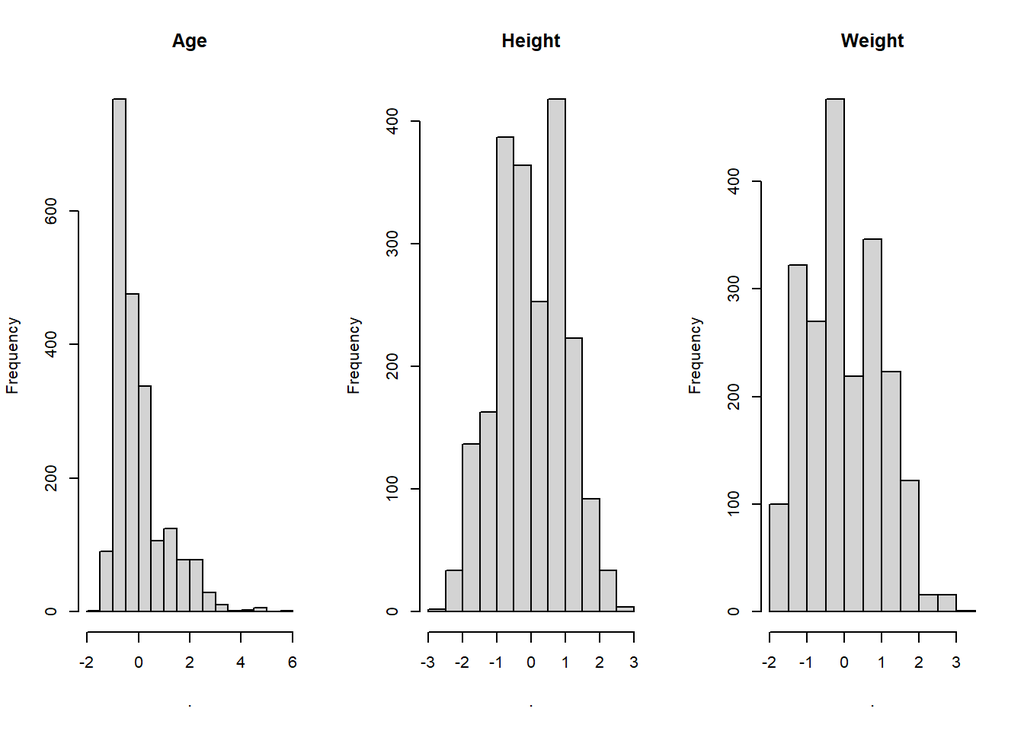

```r
vars <- processed_data %>%
  select_if(., is.numeric) %>%
  colnames(.) %>%
  as.factor(.)

par(mfrow = c(1,3))
for(levels in vars){
  processed_data %>%
    select(all_of(levels)) %>%
    as.matrix(.) %>%
    as.numeric(.) %>%
    hist(., main = as.character(levels))
}
```

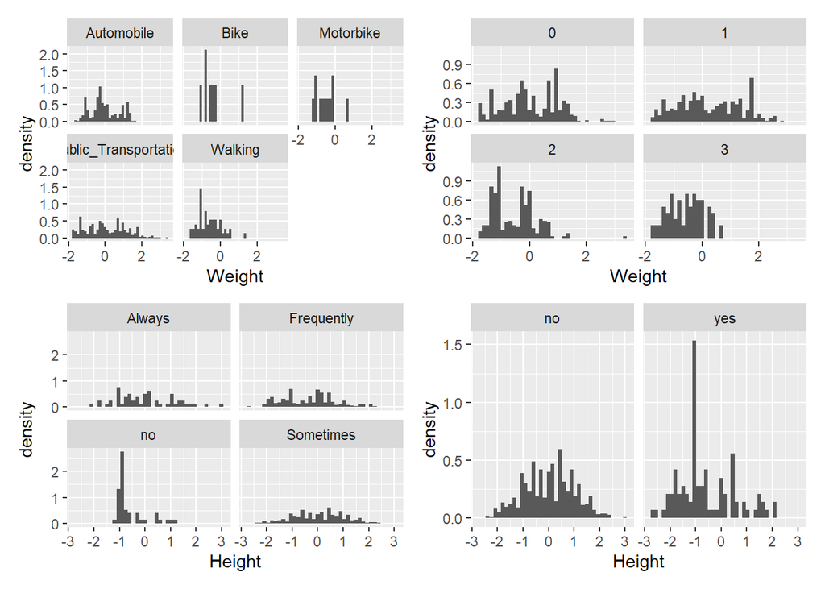

```r
hist_one <-
  ggplot(data = processed_data, aes(x = Weight)) +
  geom_histogram(aes(y = after_stat(density)), bins = 39) +
  facet_wrap(facets = "MTRANS")

hist_two <-
  ggplot(data = processed_data, aes(x = Weight)) +
  geom_histogram(aes(y = after_stat(density)), bins = 39) +
  facet_wrap(facets = "FAF")

hist_three <-
  ggplot(data = processed_data, aes(x = Height)) +
  geom_histogram(aes(y = after_stat(density)), bins = 39) +
  facet_wrap(facets = "CAEC")

hist_four <-
  ggplot(data = processed_data, aes(x = Height)) +
  geom_histogram(aes(y = after_stat(density)), bins = 39) +
  facet_wrap(facets = "SCC")

hist_one + hist_two + hist_three + hist_four + plot_layout(2, 2)
```

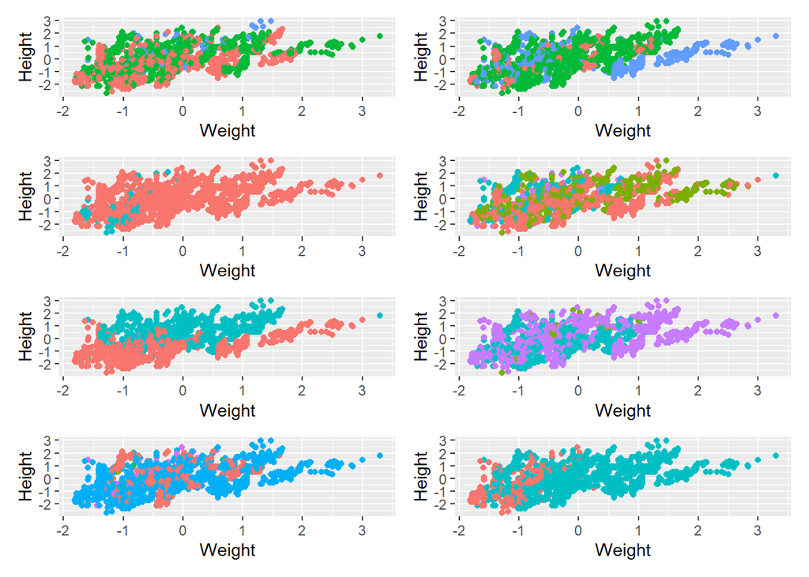

```r
plot_one <- ggplot(processed_data, aes(x = Weight, y = Height, col = as.factor(CH2O))) +
  geom_point() + theme(legend.position = "none")

plot_two <- ggplot(processed_data, aes(x = Weight, y = Height, col = as.factor(FCVC))) +
  geom_point() + theme(legend.position = "none")

plot_three <- ggplot(processed_data, aes(x = Weight, y = Height, col = as.factor(SCC))) +
  geom_point() + theme(legend.position = "none")

plot_four <- ggplot(processed_data, aes(x = Weight, y = Height, col = as.factor(FAF))) +
  geom_point() + theme(legend.position = "none")

plot_five <- ggplot(processed_data, aes(x = Weight, y = Height, col = Gender)) +
  geom_point() + theme(legend.position = "none")

plot_six <- ggplot(processed_data, aes(x = Weight, y = Height, col = CALC)) +
  geom_point() + theme(legend.position = "none")

plot_seven <- ggplot(processed_data, aes(x = Weight, y = Height, col = MTRANS)) +
  geom_point() + theme(legend.position = "none")

plot_eight <- ggplot(processed_data, aes(x = Weight, y = Height, col = Family_Occ)) +
  geom_point() + theme(legend.position = "none")

plot_one + plot_two + plot_three + plot_four + plot_five + plot_six +
  plot_seven + plot_eight + plot_layout(ncol = 2, nrow = 4)
```

Furthermore, I created eight scatterplots with Weight on the x-axis and Height on the y-axis. The plots show that the clusters do not seem to be circular, but instead elliptical, in the space of data. This is another argument in favor of GMM.

Therefore, I decided that GMM will be the first method. As for the second method, I chose for Hierarchical clustering. This is because, although we could easily use K-means clustering, as we know the number of categories in the outcome variable, I am curious whether hierarchical clustering will be able to properly show the number of correct categories in a dendrogram. For the Hierarchical clustering, I chose complete linkage in order to get a more balanced dendrogram with Euclidean distances.

To summarize, the two clustering methods I chose for the current dataset are:

- Gaussian Mixture Modeling
- Agglomerative Hierarchical Clustering with euclidean distances and complete linkage

### Applying the two methods

```r
set.seed(1248)

## First, make sure we remove the true categories variable
train_set <- processed_data %>%
  select(-NObeyesdad)

## Then, for GMM:
library(mclust)
```

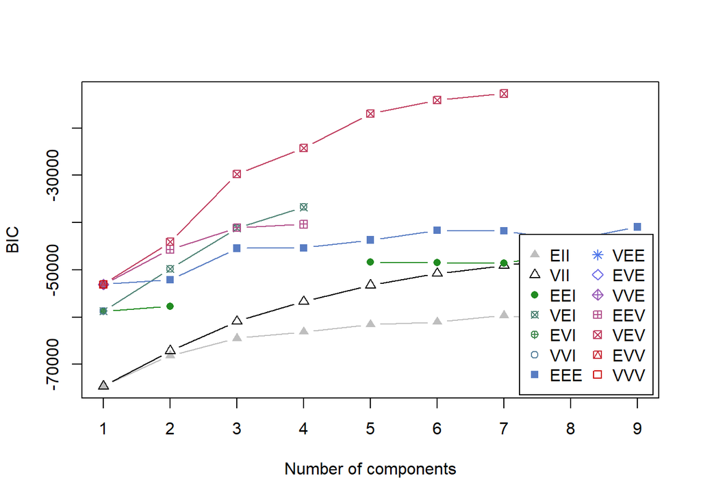

```r
## Fit the model with 1 to 9 clusters
GMM_fit <- Mclust(train_set, G = 1:9, verbose = FALSE)

## Check which model has the best BIC
plot(GMM_fit, what = "BIC")
```

```r
GMM_fit$BIC
```

```
## Bayesian Information Criterion (BIC):
##         EII       VII       EEI       VEI      EVI      VVI       EEE       VEE
## 1 -74603.89 -74603.89 -58713.10 -58713.10 -58713.1 -58713.1 -53074.13 -53074.13
## 2 -68130.82 -67163.68 -57672.80 -49818.99       NA       NA -52121.14        NA
## 3 -64473.89 -60899.19        NA -41157.74       NA       NA -45437.57        NA
## 4 -63104.27 -56715.60        NA -36730.98       NA       NA -45355.33        NA
## 5 -61569.51 -53228.48 -48367.91        NA       NA       NA -43673.84        NA
## 6 -61002.54 -50760.42 -48498.55        NA       NA       NA -41650.98        NA
## 7 -59601.61 -49080.97 -48629.44        NA       NA       NA -41781.29        NA
## 8 -61118.06 -47497.03 -46069.84        NA       NA       NA -43714.08        NA
## 9 -59662.61 -46302.48        NA        NA       NA       NA -40927.70        NA
##         EVE       VVE       EEV       VEV       EVV       VVV
## 1 -53074.13 -53074.13 -53074.13 -53074.13 -53074.13 -53074.13
## 2        NA        NA -45666.52 -44086.77        NA        NA
## 3        NA        NA -41119.70 -29727.50        NA        NA
## 4        NA        NA -40352.06 -24229.02        NA        NA
## 5        NA        NA        NA -16963.54        NA        NA
## 6        NA        NA        NA -14117.03        NA        NA
## 7        NA        NA        NA -12704.95        NA        NA
## 8        NA        NA        NA        NA        NA        NA
## 9        NA        NA        NA        NA        NA        NA
##
## Top 3 models based on the BIC criterion:
##     VEV,7     VEV,6     VEV,5
## -12704.95 -14117.03 -16963.54
```

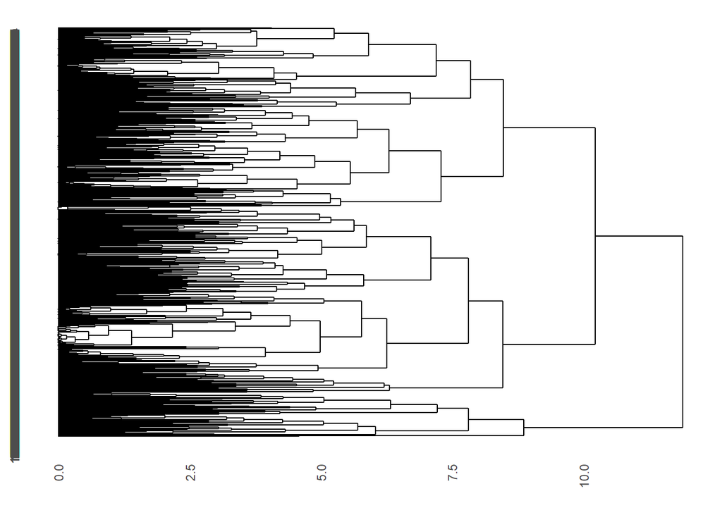

```r
## Hierarchical clustering:
library(ggdendro)
distances <- dist(train_set, method = "euclidean")
hclust_res <- hclust(distances, method = "complete")

ggdendrogram(hclust_res) + coord_flip()
```

The results of the two clustering method shows that the best fitting GMM are ones that allow for a varying shape (as all of the top three models start with a V). This is what we expected, due to the elliptical shape of the above plotted graphs. As for the hierarchical clustering method, we find that on the horizontal axis, the cut off for 7 clusters does not seem to be very far removed from 6. This might indicate that the method perhaps has issues discriminating between some clusters (for example between Overweight type I and II). Furthermore, due to the semi-categorical nature of many variables, euclidean distances might not have been the best choice.

### Evaluating and comparing the two methods

To evaluate and compare the two methods, I will compare them on three factors, namely:

1. Cluster stability, as measured by computing 100 bootstrap samples
2. Internal indices, more specifically by computing the silhouette coefficient for the two methods
3. External validity, by investigating whether the predicted categories from the two clustering methods are associated with their true category. Whether they are associated will be investigated through a $\chi^2$-test of independence and the correlation coefficient, calculated through the Spearman-Brown formula.

Below, you find the implementation for all three factors for both models.

```r
## Stability
library(fpc)

## For the hclust method
hclust_boot <- train_set %>%
  ## First, we have to recode all factors back to numerics, otherwise
  ## the method does not work
  mutate(Gender = as.numeric(Gender) - 1,
         FAVC = as.numeric(FAVC) - 1,
         FCVC = as.numeric(FCVC) - 1,
         NCP = as.numeric(NCP) - 1,
         CAEC = as.numeric(CAEC) - 1,
         SMOKE = as.numeric(SMOKE) - 1,
         CH2O = as.numeric(CH2O) - 1,
         SCC = as.numeric(SCC) - 1,
         FAF = as.numeric(FAF) - 1,
         TUE = as.numeric(TUE) - 1,
         CALC = as.numeric(CALC) - 1,
         MTRANS = as.numeric(MTRANS) - 1,
         Family_Occ = as.numeric(Family_Occ) - 1) %>%
  ## Then we specify the method we want the stability for
  clusterboot(data = ., B = 100, k = 7, count = FALSE,
              clustermethod = hclustCBI,
              method = "complete", cutree = "7")

## And we check the stability of the 7 clusters
hclust_boot$bootmean
```

```
## [1] 0.7022012 0.6246077 0.1593760 0.8896614 0.4056160 0.6663713 0.4825232
```

```r
## And we do the same for the GMM clustering method
mclust_boot <- train_set %>%
  mutate(Gender = as.numeric(Gender) - 1,
         FAVC = as.numeric(FAVC) - 1,
         FCVC = as.numeric(FCVC) - 1,
         NCP = as.numeric(NCP) - 1,
         CAEC = as.numeric(CAEC) - 1,
         SMOKE = as.numeric(SMOKE) - 1,
         CH2O = as.numeric(CH2O) - 1,
         SCC = as.numeric(SCC) - 1,
         FAF = as.numeric(FAF) - 1,
         TUE = as.numeric(TUE) - 1,
         CALC = as.numeric(CALC) - 1,
         MTRANS = as.numeric(MTRANS) - 1,
         Family_Occ = as.numeric(Family_Occ) - 1) %>%
  clusterboot(data = ., B = 100, count = FALSE, k = 7,
              clustermethod = noisemclustCBI, G = 7,
              multipleboot = FALSE, verbose = FALSE)

mclust_boot$bootmean
```

[output not shown]

```r
## Silhouette (Internal indices)
library(cluster)

## Through silhouette function, we can easily get this for:

## The hierarchical clustering method:
silhouette(x = (cutree(hclust_res, 7)), dist = distances) %>%
  summary(.)
```

```
## Silhouette of 2111 units in 7 clusters from silhouette.default(x = (cutree(hclust_res, 7)), dist = distances) :
##  Cluster sizes and average silhouette widths:
##        861        101        513        141        220        267          8
## 0.02629078 0.21876995 0.04015752 0.11632420 0.09776151 0.26663449 0.51752735
## Individual silhouette widths:
##     Min.  1st Qu.   Median     Mean  3rd Qu.     Max.
## -0.36596 -0.01871  0.10183  0.08459  0.19381  0.60785
```

```r
## The GMM clustering method:
silhouette(x = GMM_fit$classification, dist = distances) %>%
  summary(.)
```

```
## Silhouette of 2111 units in 7 clusters from silhouette.default(x = GMM_fit$classification, dist = distances) :
##  Cluster sizes and average silhouette widths:
##         714         380          38         735         119          48
## -0.05391042 -0.08656582  0.76849335 -0.11328008  0.71511933  0.61353309
##          77
##  0.48948436
## Individual silhouette widths:
##     Min.  1st Qu.   Median     Mean  3rd Qu.     Max.
## -0.77579 -0.15847 -0.03355  0.01269  0.07995  0.83669
```

```r
## External validity

## We create a contingency table between the predicted and true classes
## for the hierarchical clustering method
table(true = processed_data$NObeyesdad,
      hclust = as.factor(cutree(hclust_res, 7))) %>%
  ## And check whether they are associated wwith one another
  chisq.test(.)
```

```
##
##  Pearson's Chi-squared test
##
## data:  .
## X-squared = 1072.6, df = 36, p-value < 2.2e-16
```

```r
## The same is done for the GMM clustering method
table(true = processed_data$NObeyesdad, mclust = GMM_fit$classification) %>%
  chisq.test(.)
```

```
##
##  Pearson's Chi-squared test
##
## data:  .
## X-squared = 2551.2, df = 36, p-value < 2.2e-16
```

```r
## Besides this, we also get the Spearman-Brown correlation coefficient
## between the predicted and true categories

## For both the hierarchical clustering method
cbind(processed_data$NObeyesdad, as.factor(cutree(hclust_res, 7))) %>%
  cor(x = ., method = "spearman")
```

```
##            [,1]       [,2]
## [1,] 1.00000000 0.07185633
## [2,] 0.07185633 1.00000000
```

```r
## And the GMM clustering method
cbind(processed_data$NObeyesdad, GMM_fit$classification) %>%
  cor(x = ., method = "spearman")
```

```
##           [,1]      [,2]
## [1,] 1.0000000 0.3105452
## [2,] 0.3105452 1.0000000
```

The three comparisons show that the Gaussian Mixture Model has: (a) a higher average stability for the Gaussian Mixture Model, (b) higher values on the average silhouette per cluster and (c) a higher external validity correlation value. Although the $\chi^2$-tests of independence was significant for both models, this might be due to a large sample size. Because looking at the correlation, we find that the clusters made by the Hierarchical Clustering method has a correlation of only 0.07 with the true clusters. The Gaussian Mixture Model’s predicted clusters instead had a correlation of 0.31. However, I would argue that the external validity for the Gaussian Mixture Model is still somewhat low.

## Conclusion

Looking back at the two different clustering methods, I think a few things become clear. First and foremost, we can safely state that a Gaussian Mixture Model with elliptical shapes was able to outperform an agglomerative hierarchical clustering method, as shown by the comparison above. However, there are still many issues to be had with the Gaussian Mixture modelling. For example, many of the Gaussian Mixture Models were not able to converge (as seen by the NAs in the output). Furthermore, many of the variables that we used for the clustering method were of a categorical nature (or atleast, not quite on an interval measurement level). And for both models, this might have lead to issues. For the agglomerative clustering method, euclidean distances might not have been the best choice for example. Furthermore, since the variables are not completely on an interval measurement level, does it make sense for us to assume they follow a normal distribution? Perhaps it would have been better to compute a ‘total score’ made up by multiple of the categorical variables and use this instead. To summarise, although we were able to achieve some succes in our clustering methods, there were still many limitations we have to keep in mind and further research would be necessary in order to improve the predicted clusters.